# PUBHBIO 6211: Practice Exercises Block 8

# Exercise 1

A small study of two new herbal supplements for weight loss for severely obese subjects was conducted. A total of 12 subjects were recruited and were randomized to receive either placebo, herb 1, or herb 2. Researchers wanted to know if the average weight at the six-month point of the study is the same in all three groups, so they conducted an ANOVA analysis. A partial Stata output is below.

```stata
. oneway weight group

                        Analysis of Variance
    Source              SS         df      MS            F     Prob > F
------------------------------------------------------------------------
Between groups      14816.6667    (a)   ____(c)___     _(e)_     __(f)_
 Within groups            5275    (b)   ____(d)___
------------------------------------------------------------------------
    Total           20091.6667     11   1826.51515

Bartlett's test for equal variances:  chi2(2) =   1.5752  Prob>chi2 = 0.455
```

1. Fill in all the blanks with the missing quantities (labeled with letters.) (Use Stata to find p-value.)
2. Write a one-sentence conclusion summarizing the result of the ANOVA.
3. Pairwise comparisons were conducted, resulting in the output below. The *unadjusted* p-values are shown. Calculate the Bonferroni-adjusted p-values and summarize the results.

```stata
. anova weight group
. pwcompare group, mcompare(noadjust) effects

------------------------------------------------------------------------------------
                   |                            Unadjusted           Unadjusted
                   |   Contrast   Std. Err.      t    P>|t|     [95% Conf. Interval]
-------------------+----------------------------------------------------------------
             group |
herb 1 vs placebo  |       67.5   17.11887     3.94   0.003     28.77444    106.2256
herb 2 vs placebo  |      -12.5   17.11887    -0.73   0.484    -51.22556    26.22556
 herb 2 vs herb 1  |        -80   17.11887    -4.67   0.001    -118.7256   -41.27444
------------------------------------------------------------------------------------
```

# Exercise 2

A survey of a random sample of students at the University of New Hampshire was conducted. We are interested in predictors of grade point average (GPA), which is measured on a 4-point scale. We are interested in whether there are differences in GPA by students’ religious preferences (`relig`: 1=Protestant, 2=Catholic, 3=Jewish, 4=Other). Use the Stata output below to write a short summary of the findings.

```stata
. anova gpa relig

                         Number of obs =        214    R-squared     =  0.0439
                         Root MSE      =    .448623    Adj R-squared =  0.0302

                  Source | Partial SS         df         MS        F    Prob>F
              -----------+----------------------------------------------------
                   Model |  1.9385636          3   .64618787      3.21  0.0240
                         |
                   relig |  1.9385636          3   .64618787      3.21  0.0240
                         |
                Residual |  42.265126        210    .2012625
              -----------+----------------------------------------------------
                   Total |   44.20369        213   .20752906

. pwcompare relig, mcompare(tukey) effects

------------------------------------------------------------------------------
             |                              Tukey                Tukey
             |   Contrast   Std. Err.      t    P>|t|     [95% Conf. Interval]
-------------+----------------------------------------------------------------
       relig |
     2 vs 1  |  -.1750524   .0824899    -2.12   0.149    -.3886782    .0385735
     3 vs 1  |   .0894643    .114795     0.78   0.864    -.2078228    .3867514
     4 vs 1  |  -.0399107   .0947889    -0.42   0.975    -.2853874     .205566
     3 vs 2  |   .2645167   .1019733     2.59   0.049     .0004342    .5285991
     4 vs 2  |   .1351417   .0787756     1.72   0.318    -.0688651    .3391484
     4 vs 3  |   -.129375   .1121557    -1.15   0.657     -.419827     .161077
------------------------------------------------------------------------------
```

# Exercise 3

A survey of a random sample of students at the University of New Hampshire was conducted. Information was collected on the amount of alcohol students consumed. The result was a 33-point drinking scale score, where a higher score means more alcohol consumption. We are interested in whether there are differences in alcohol consumption among the years in school (`year`: 1=Freshman, 2=Sophomore, 3=Junior, 4=Senior), and also differences by gender (`gender`: 1=male, 0=female). Note that gender is operationalized as a binary (2-level) variable in these (old) data.

```stata
. anova drink year gender year#gender

                         Number of obs =        243    R-squared     =  0.1548
                         Root MSE      =    6.27145    Adj R-squared =  0.1296

                  Source | Partial SS         df         MS        F    Prob>F
             ------------+----------------------------------------------------
                   Model |  1692.4077          7   241.77253      6.15  0.0000
                         |
                    year |  535.75564          3   178.58521      4.54  0.0041
                  gender |  690.66036          1   690.66036     17.56  0.0000
             year#gender |  174.46164          3    58.15388      1.48  0.2210
                         |
                Residual |  9242.8104        235   39.331108
             ------------+----------------------------------------------------
                   Total |  10935.218        242   45.186852
```

1. The result of a two-way ANOVA is below. Explain the results of the appropriate hypothesis tests.
2. What is an appropriate next analysis to do?
3. An ANOVA plot for this model is also shown below. Explain how the results of the ANOVA are illustrated by the plot.

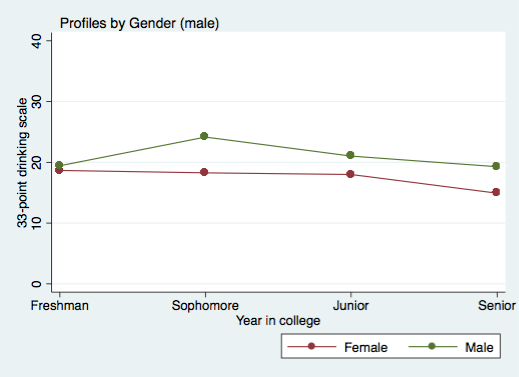

ANOVA Plot

# Exercise 4

A lab experiment was conducted to assess the effect of 4 levels of exercise and 3 types of diets on weight gain in hamsters. Two hamsters were assigned to each exercise/diet group and the weight gain for each hamster was measured (in grams). The result of a two-way ANOVA is below. Explain the results of the appropriate hypothesis tests.

```stata
. anova wtgain exercise diet diet#exercise

                         Number of obs =         24    R-squared     =  0.7736
                         Root MSE      =    2.82843    Adj R-squared =  0.5660

                  Source | Partial SS         df         MS        F    Prob>F
           --------------+----------------------------------------------------
                   Model |        328         11   29.818182      3.73  0.0163
                         |
                exercise |        144          3          48      6.00  0.0097
                    diet |        112          2          56      7.00  0.0097
           diet#exercise |         72          6          12      1.50  0.2586
                         |
                Residual |         96         12           8
           --------------+----------------------------------------------------
                   Total |        424         23   18.434783
```

# Exercise 5

Continuing the analysis from the previous problem, pairwise comparisons were conducted using a Tukey adjustment. Stata output is below. Write a short summary of the results. The levels of the variables are as follows.

- exercise: 1=None, 2=Mild, 3=Moderate, 4=Heavy
- diet: 1=Diet A, 2=Diet B, 3=Diet C

```stata
. pwcompare exercise, mcompare(tukey) effects

------------------------------------------------------------------------------
             |                              Tukey                Tukey
             |   Contrast   Std. Err.      t    P>|t|     [95% Conf. Interval]
-------------+----------------------------------------------------------------
    exercise |
     2 vs 1  |          2   1.632993     1.22   0.624    -2.848195    6.848195
     3 vs 1  |   8.88e-16   1.632993     0.00   1.000    -4.848195    4.848195
     4 vs 1  |          6   1.632993     3.67   0.015     1.151805     10.8482
     3 vs 2  |         -2   1.632993    -1.22   0.624    -6.848195    2.848195
     4 vs 2  |          4   1.632993     2.45   0.120    -.8481952    8.848195
     4 vs 3  |          6   1.632993     3.67   0.015     1.151805     10.8482
------------------------------------------------------------------------------

. pwcompare diet, mcompare(tukey) effects

------------------------------------------------------------------------------
             |                              Tukey                Tukey
             |   Contrast   Std. Err.      t    P>|t|     [95% Conf. Interval]
-------------+----------------------------------------------------------------
        diet |
     2 vs 1  |          5   1.414214     3.54   0.011     1.227071    8.772929
     3 vs 1  |          4   1.414214     2.83   0.038     .2270711    7.772929
     3 vs 2  |         -1   1.414214    -0.71   0.764    -4.772929    2.772929
------------------------------------------------------------------------------
```